# ARIMA

Волканова Маргарита

16 мая 2019 г

# 1 Auto Regressive Integrated Moving Average proceses

Стационарны процессы:
$$x_t=c+\sum_{i=1}^{p}\phi_ix_{t-i}+\epsilon_t,$$
$\epsilon_t$ - независима от $x_{t-i}$, $E\epsilon_t=0, D\epsilon_t=\sigma^2$. Условие на $\phi_t$: $x_t$ - стационарный.

## 1.1 Модель авторегрессии AR через оператор сдвига

Пусть $с=0_p$
$$L: Lx_t = x_{t-1}$$
$$x_t=\sum_{i=1}^{p}\phi_iL^ix_t+\epsilon_t$$
Модель авторегресии
$$\epsilon_t=(1-\sum_{i=1}^p\phi_iL^i)x_t = \Phi_p(L)x_t,$$
где $\Phi_p$ - хар. полином.

## 1.2 AR(p) и модель сигнала в SSA

Пусть существует
$$S_t = \sum_{i=1}^p \phi_i s_{t-i} \text{ - сигнал, где } x_t=s_t+\epsilon_t$$
.

Модель авторегресси имеет вид:
$$x_t=\sum_{i=1}^p \phi_i x_{t-i} + \epsilon_t$$
(Для SSA - шум добавляется к всему сигналу, а в AR на каждом шаге.)

Построим для них acf и pacf.

pacf - частная автокорреляция - обычная корреляция между остатками после регрессии.
$$pacf(m)= \rho ( x_t,x_{t+m} \text{; } x_{t+1} \ldots x_{t+m-1})$$

Пунктирными линиями на графиках отмечен критический интервал $[-\frac{2}{\sqrt{n}},\frac{2}{\sqrt{n}}]$, в пределах которых ACF и PACF считаются не отличающимися от нуля.

```r
library("forecast")
library("Rssa")
data <-read.csv('D:/Golyandina/arima/ts2.txt', sep="\t", header=TRUE)
data<-ts(data)
auto.arima(data)
```

```
## Series: data
## ARIMA(0,0,2) with non-zero mean
##
## Coefficients:
##          ma1     ma2    mean
##       0.2324  0.1128  1.0083
## s.e.  0.0223  0.0224  0.0441
##
## sigma^2 estimated as 2.151:  log likelihood=-3602.17
## AIC=7212.34   AICc=7212.36   BIC=7234.74
```

```r
arima(data)
```

```
##
## Call:
## arima(x = data)
##
## Coefficients:
##       intercept
##          1.0082
## s.e.     0.0338
##
## sigma^2 estimated as 2.288:  log likelihood = -3665.62,  aic = 7335.24
```

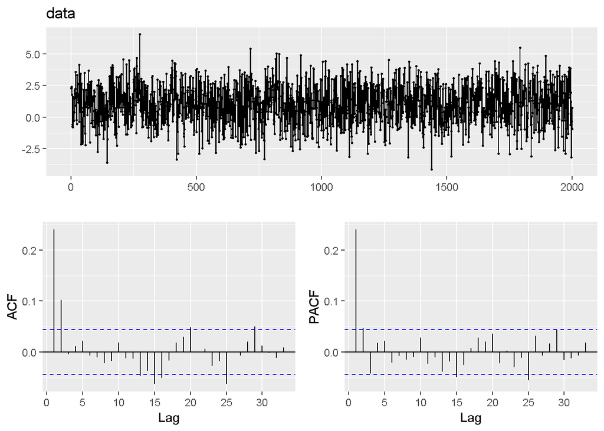

```r
ggtsdisplay(data)
```

То есть ARMA(0,0,2) уравнение имеет вид:
$$z_t=1.008+x_t+0.003, x_t=\epsilon_t+0.232\epsilon_{t-1}+0.113\epsilon_{t-2}$$
По количеству столбцов ACF, значимо отличающихся от нуля, можно определить количество параметров в модели. У нас два, собственно что и требуется. (MA(2), acf(m)=0 при m>2)

## 1.3 AIC,BIC

Выбрать модель можно по критерию AIC(Информационный критерий Акаике):
$$AIC=-2\ln L+2k,$$
где $\ln L$ - логарифм функции правдоподобия, а $k$ - число параметров модели.

Чем больше параметров, $k$, тем сложнее модель, тем выше AIC. Чем ниже функция правдоподобия, L, то есть, чем ниже вероятность получить имеющиеся данные при данной модели, тем выше AIC.

```r
ar002 <- Arima(data, order = c(0, 0, 2))
ar101 <- Arima(data, order = c(1, 0, 1))
c(AIC(ar002),AIC(ar101))
```

```
## [1] 7212.339 7217.465
```

Видим, что по AIC модель (0,0,2) лучше

Критерий BIC (Байесовский информационный критерий):
$$BIC=-2\ln L+\ln nk,$$

```r
c(BIC(ar002),BIC(ar101))
```

```
## [1] 7234.743 7239.869
```

По данном критерию модель (0,0,2) лучше.

Посмотрим остатки

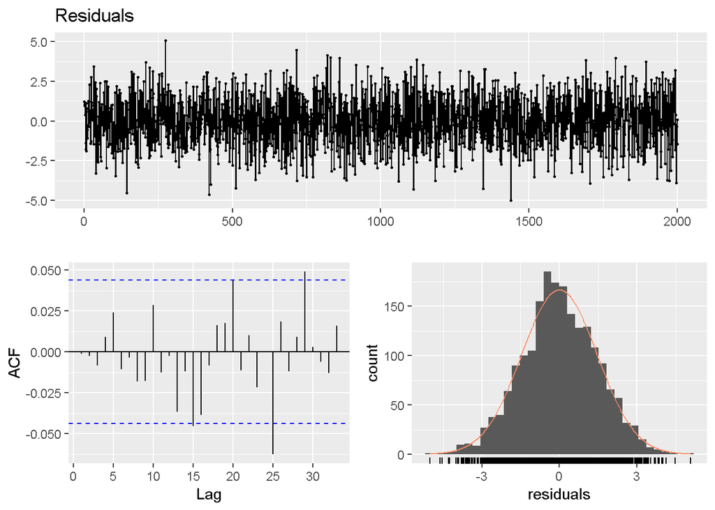

```r
checkresiduals(resid(ar002))
```

```r
#fitdf - число степеней свободы p+q=2
#Для несезонных рядов рекомендует брать lag=10
Box.test(resid(ar002), lag = 10, type = "Ljung-Box",fitdf=2)
```

```
##
##  Box-Ljung test
##
## data:  resid(ar002)
## X-squared = 4.6797, df = 8, p-value = 0.7912
```

Получаем, что гипотеза белого шума не отвергается, а значит модель корректно описывает структуру корреляции.

# 2 ets для модельного ряда

Посмотрим какю модель он определит сам

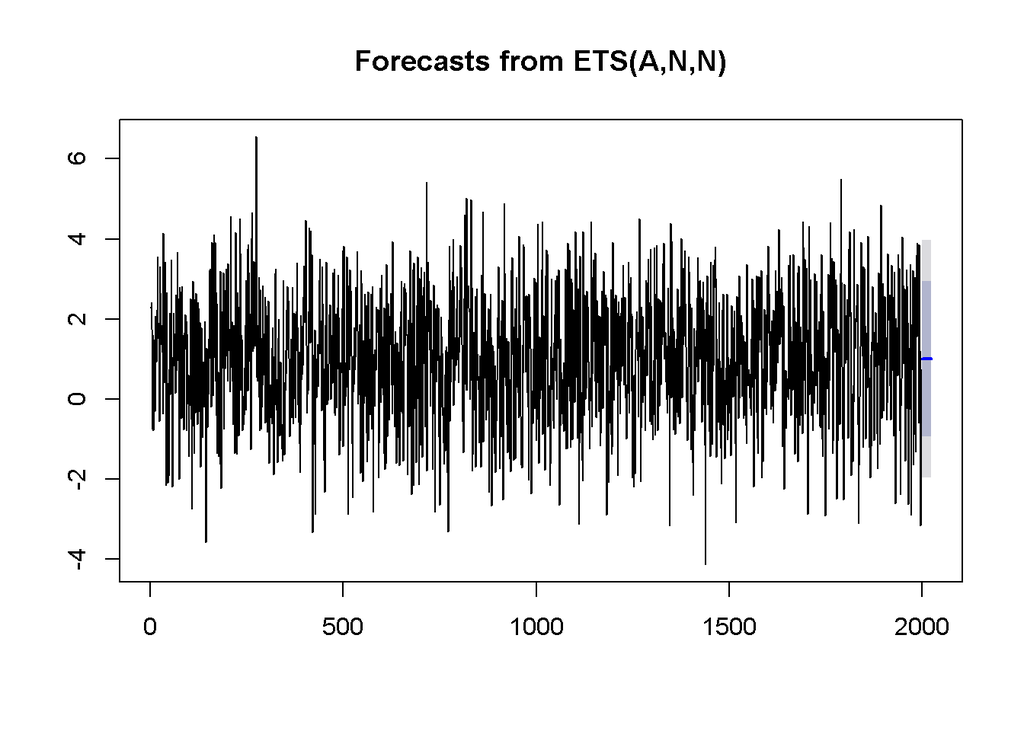

```r
data.ets<-forecast(ets(data),h=24)
plot(data.ets)
```

Теперь посмотрим как он построит модель AАN

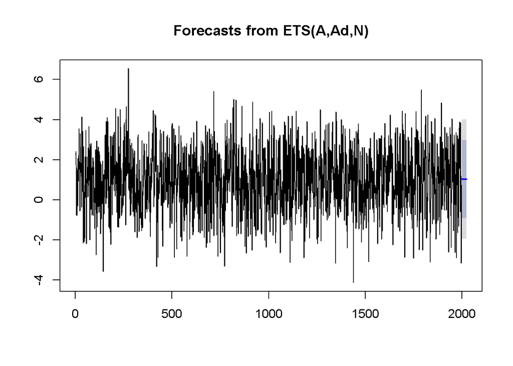

```r
data.ets<-forecast(ets(data,model = "AAN"),h=24)
plot(data.ets)
```

```r
#lines(fort_old, col="red")
```

## 2.1 Вид автоковариационной функции acf для AR(p)

## 2.2 AR(p)

Смоделируем данные для авторегрессии порядка 1 с разными по знаку коэффициентами. Построим для них acf и pacf .

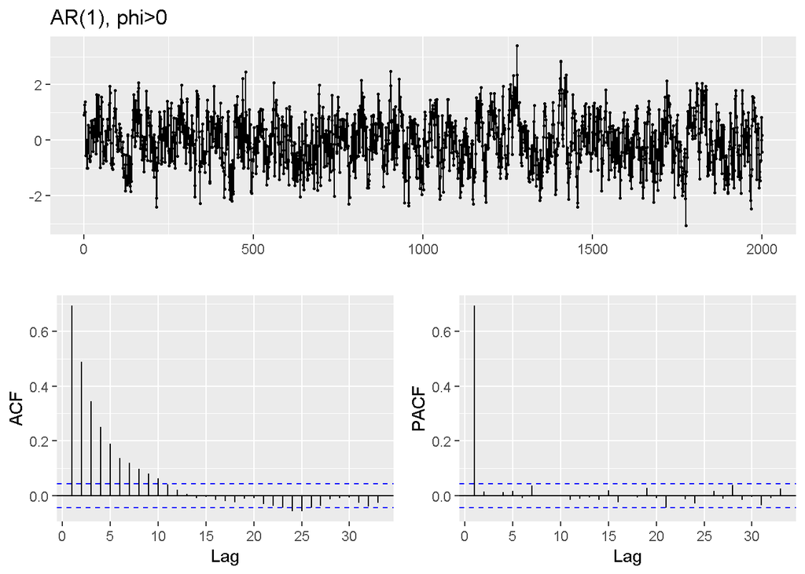

```r
set.seed(1)#фиксатор - чтобы получить один и тот же набор случайных чисел для каждого вызова функции
AR_1 <- arima.sim(n = 2000, list(order = c(1,0,0), ar = 0.7), sd = sqrt(0.4))
ggtsdisplay(AR_1, main ="AR(1), phi>0" )
```

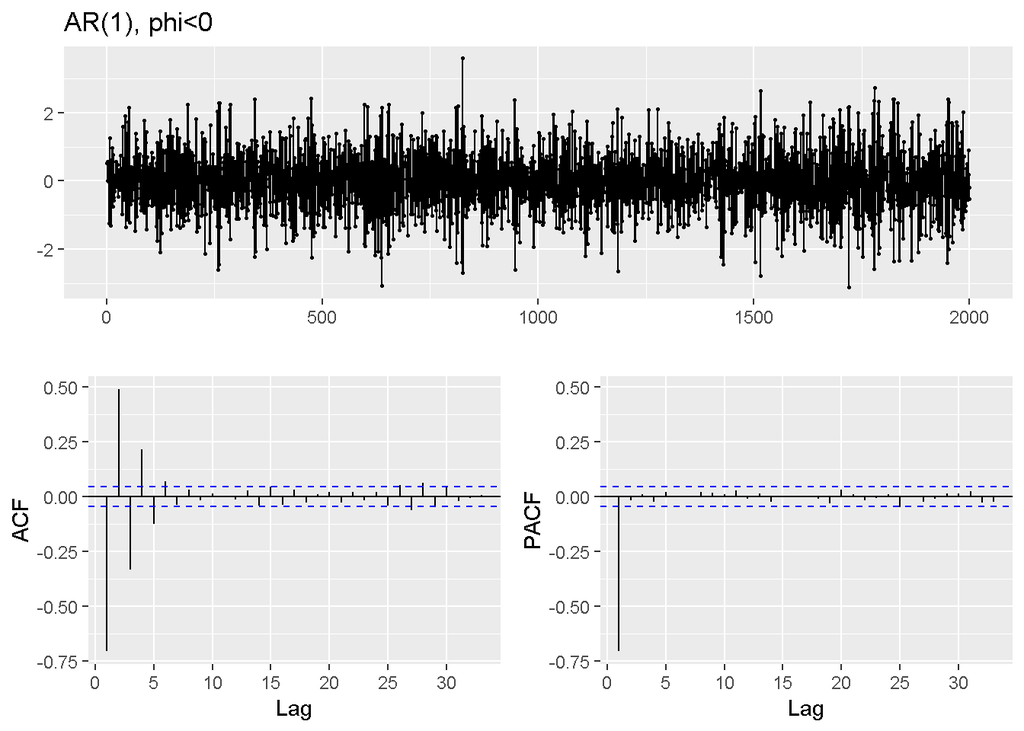

```r
set.seed(1)
AR_1_ <- arima.sim(n = 2000, list(order = c(1,0,0), ar = -0.7), sd = sqrt(0.4))
ggtsdisplay(AR_1_,main ="AR(1), phi<0" )
```

В обоих случаях видим на PACF один скачок.

# 3 Модель MA(q)

Модель скользящего среднего (т.е. это скользящее среднее к белому шуму)
$$X_t=\epsilon_t+\sum_{i=1}^q Q_i\epsilon_{t-i}$$
$\epsilon_t$ - белый шум, $Q_i$ - параметры.

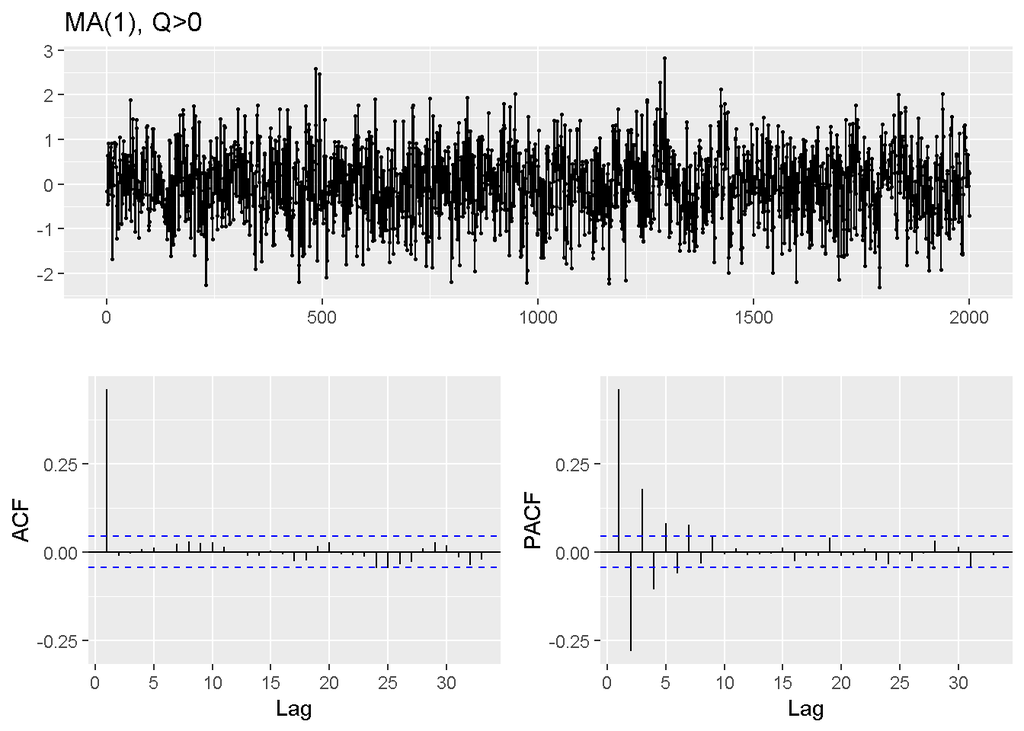

```r
set.seed(1)
MA_1 <- arima.sim(n = 2000, list(order = c(0,0,1), ma = 0.7), sd = sqrt(0.4))
ggtsdisplay(MA_1,main ="MA(1), Q>0" )
```

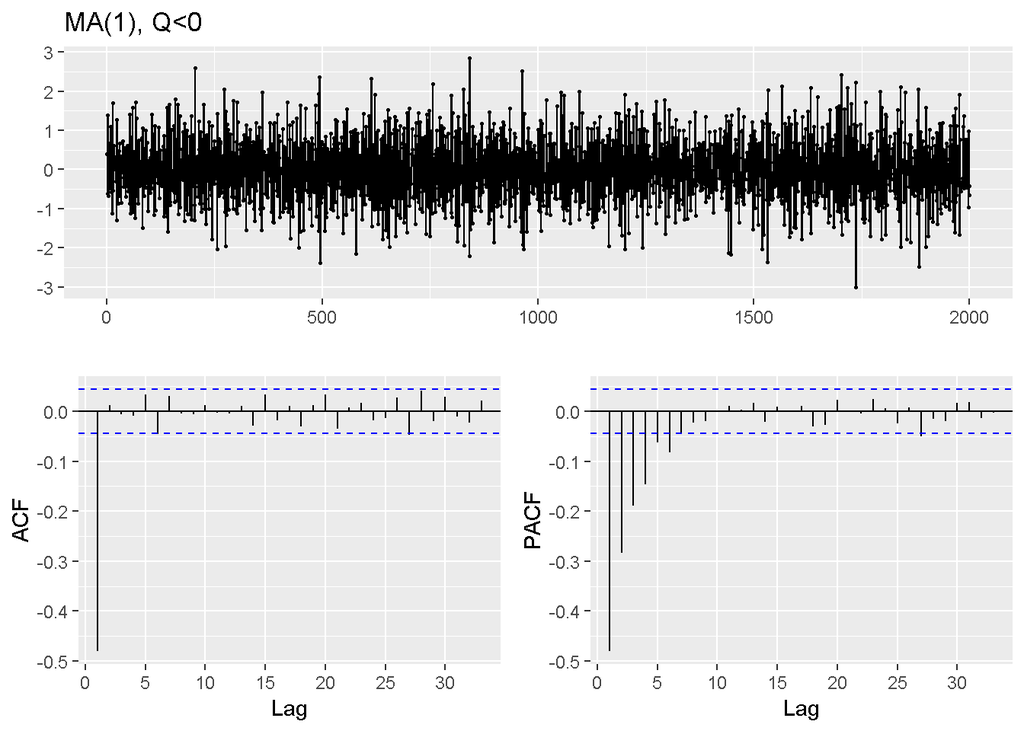

```r
set.seed(1)
MA_1_ <- arima.sim(n = 2000, list(order = c(0,0,1), ma = -0.7), sd = sqrt(0.4))
ggtsdisplay(MA_1_,main ="MA(1), Q<0" )
```

В обоих случаях видим на ACF один скачок.

## 3.1 ARMA(p,q)

Модель ARMA(p,q) выглядит следующим образом:
$$X_t=c+\sum_{i=1}^{p}\phi_ix_{t-i}+\epsilon_t+\sum_{i=1}^q Q_i\epsilon_{t-i}$$
Используя операторы сдвига:
$$\Phi_p(L)x_t=H_q(L)\epsilon_t,$$
где $H_q$ - полином порядка q.

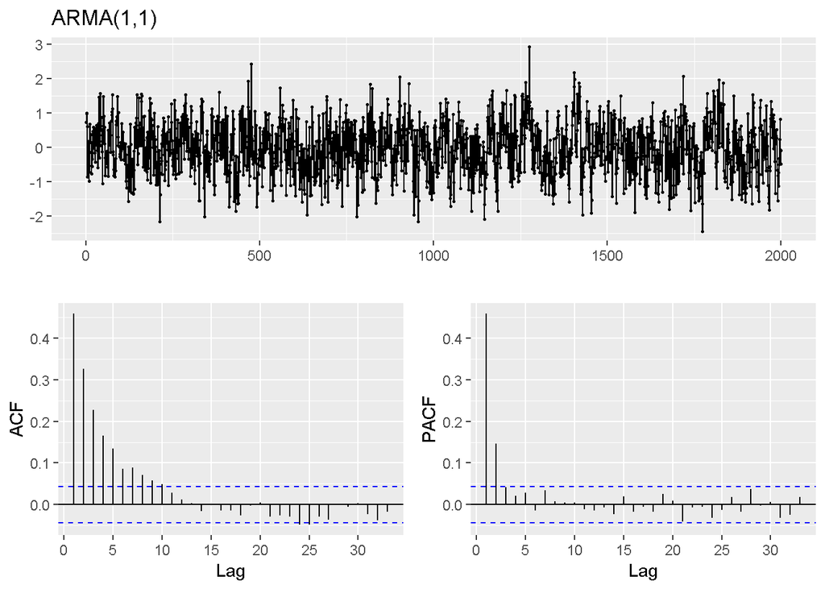

```r
set.seed(1)
ARMA_11 <- arima.sim(n = 2000, list(order = c(1,0,1), ma = -0.3,arg=0.7), sd = sqrt(0.4))
ggtsdisplay(ARMA_11,main ="ARMA(1,1)" )
```

## 3.2 ARIMA(p,d,q)

Модель ARIMA(p,d,q) c помощью операторов сдвига:
$$\Phi_p(L)(1-L)^dx_t=H_q(L)\epsilon_t$$

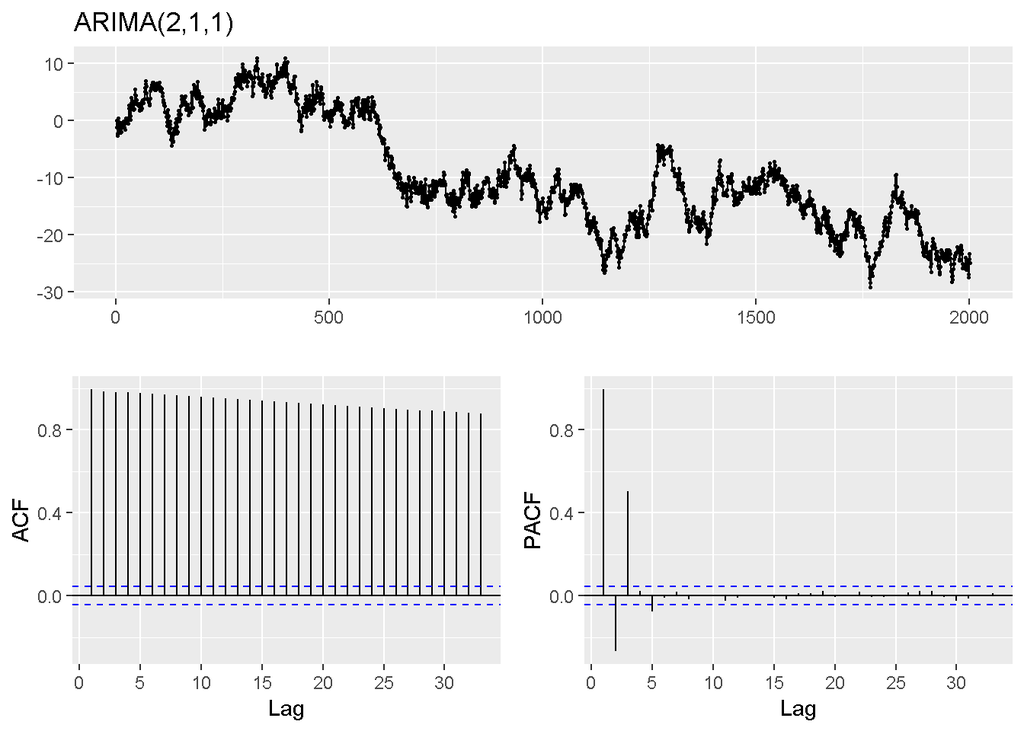

```r
set.seed(1)
ARIMA_211 <- arima.sim(n = 2000, list(ar = c(0.4, -0.6), ma = 0.3, order = c(2,1,1)), sd = sqrt(0.4))
ggtsdisplay(ARIMA_211,main ="ARIMA(2,1,1)" )
```

Перейдем к разностям.

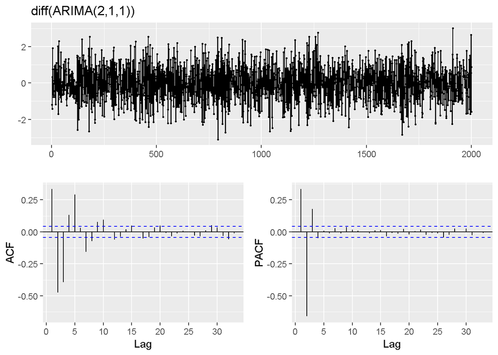

```r
library( aTSA)
ARIMA_211.diff <- diff(ARIMA_211)
ggtsdisplay(ARIMA_211.diff,main ="diff(ARIMA(2,1,1))" )
```

```r
#Проверим на стационарность ряд - альтернативная гипотеза
adf.test(ARIMA_211.diff)
```

```
## Augmented Dickey-Fuller Test
## alternative: stationary
##
## Type 1: no drift no trend
##      lag   ADF p.value
## [1,]   0 -31.6    0.01
## [2,]   1 -57.1    0.01
## [3,]   2 -29.3    0.01
## [4,]   3 -25.6    0.01
## [5,]   4 -22.0    0.01
## [6,]   5 -19.9    0.01
## [7,]   6 -17.7    0.01
## [8,]   7 -16.7    0.01
## Type 2: with drift no trend
##      lag   ADF p.value
## [1,]   0 -31.6    0.01
## [2,]   1 -57.1    0.01
## [3,]   2 -29.3    0.01
## [4,]   3 -25.7    0.01
## [5,]   4 -22.0    0.01
## [6,]   5 -19.9    0.01
## [7,]   6 -17.7    0.01
## [8,]   7 -16.7    0.01
## Type 3: with drift and trend
##      lag   ADF p.value
## [1,]   0 -31.6    0.01
## [2,]   1 -57.1    0.01
## [3,]   2 -29.3    0.01
## [4,]   3 -25.7    0.01
## [5,]   4 -22.0    0.01
## [6,]   5 -19.9    0.01
## [7,]   6 -17.7    0.01
## [8,]   7 -16.7    0.01
## ----
## Note: in fact, p.value = 0.01 means p.value <= 0.01
```

```r
#Ряд - стационарный, то есть d=1
```

Дальше, чтобы определить модель смотрим acf и pacf. Вот здесь считем p:pacf(m)=0,m>p для AR(p). Для MA(q) - наоборот, p:acf(m)=0,m>p.

У pacf явно вылез второй элемент, а вот для acf как будто и 3 подходят. Посмотрим AIC BIC

```r
ar213 <- Arima(data, order = c(2, 1, 3))
ar212 <- Arima(data, order = c(2, 1, 2))
ar211 <- Arima(data, order = c(2, 1, 1))
c(AIC(ar213),AIC(ar212),AIC(ar211))
```

```
## [1] 7220.483 7220.039 7220.668
```

Для AIC почти одинаковые все, на сотые различаются.

```r
c(BIC(ar213),BIC(ar212),BIC(ar211))
```

```
## [1] 7254.085 7248.041 7243.070
```

А по BIC явно видим, что нам нужна третья модель.

Смотрим авторегрессию.

```r
auto.arima(ARIMA_211)
```

```
## Series: ARIMA_211
## ARIMA(2,1,1)
##
## Coefficients:
##          ar1      ar2     ma1
##       0.4038  -0.6108  0.2791
## s.e.  0.0254   0.0199  0.0313
##
## sigma^2 estimated as 0.4326:  log likelihood=-1999.2
## AIC=4006.41   AICc=4006.43   BIC=4028.81
```

# 4 Seasonal ARIMA(p,d,q)(P,D,Q) (Сезонная авторегрессия)

$\Phi_p$ - полином порядка p, $\Phi_P^s$ - полином порядка P,s - период.

Воспользуюсь данными из прошлого отчета.

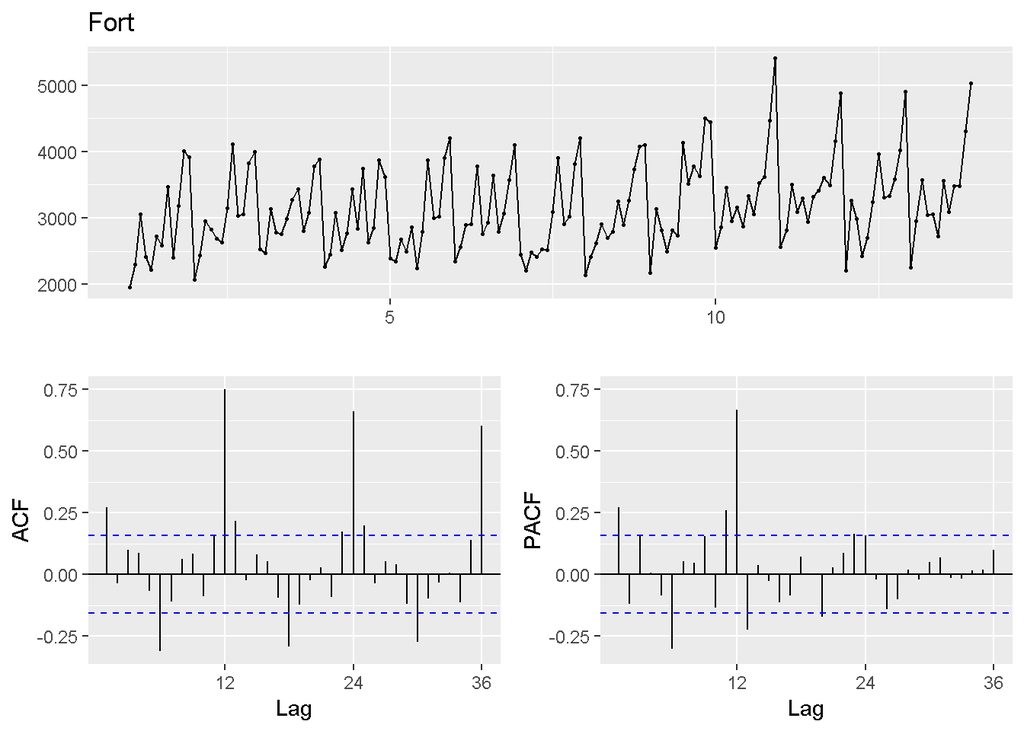

```r
data("AustralianWine")
wine <- window(AustralianWine, end = time(AustralianWine)[180])
fort<- ts(wine[, "Drywhite"],frequency = 12)#fort_old
#Здесь я делаю замену, беру за fort часть ряда
wine_ol <- window(AustralianWine, end = time(AustralianWine)[156])
fort_train<- ts(wine_ol[, "Drywhite"],frequency = 12)#fort


fort_test<-ts(wine[157:180,"Drywhite"],frequency = 12)
ggtsdisplay(fort_train,main ="Fort" )
```

### 4.0.1 ARIMA

```r
summary(auto.arima(fort_train))
```

```
## Series: fort_train
## ARIMA(0,0,1)(0,1,1)[12] with drift
##
## Coefficients:
##          ma1     sma1   drift
##       0.1935  -0.5897  3.4628
## s.e.  0.0827   0.0746  1.2254
##
## sigma^2 estimated as 101133:  log likelihood=-1035.14
## AIC=2078.27   AICc=2078.56   BIC=2090.15
##
## Training set error measures:
##                    ME     RMSE      MAE        MPE     MAPE      MASE
## Training set 4.415141 302.3382 215.6991 -0.6067489 6.978213 0.7392581
##                     ACF1
## Training set 0.006501002
```

```r
#drift - сдвиг
```

Спрогнозируем 24 точки и сравним с истинными значениями.

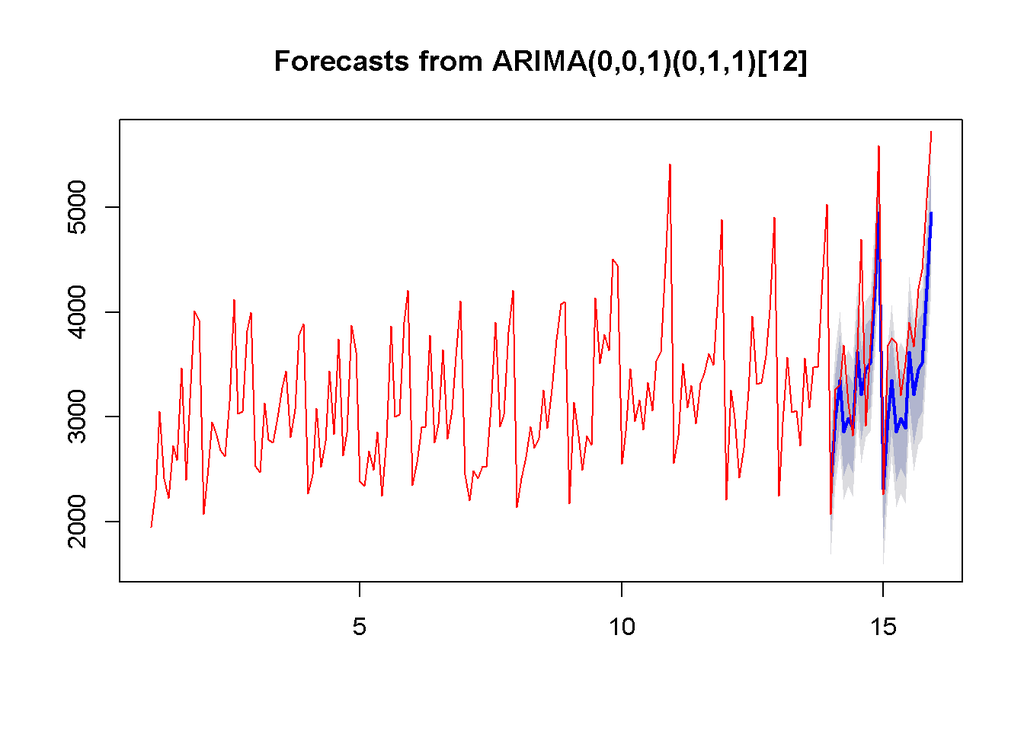

```r
fort_train.arima <- arima(fort_train, order = c(0,0,1), seasonal = list(order = c(0,1,1), period = 12))

plot(forecast::forecast(fort_train.arima, h = 24))
lines(fort, col="red")
```

Убедимся, что остатки модели временного ряда выглядят как белый шум

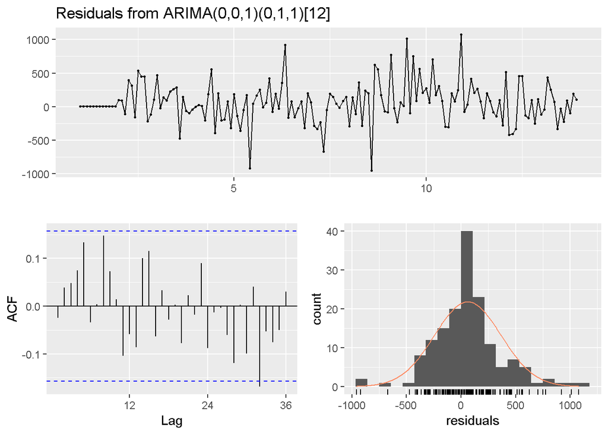

```
##
##  Ljung-Box test
##
## data:  Residuals from ARIMA(0,0,1)(0,1,1)[12]
## Q* = 22.32, df = 22, p-value = 0.441
##
## Model df: 2.   Total lags used: 24
```

```r
checkresiduals(fort_train.arima)
```

Вроде как по тесту все хорошо, да и гистограмма имеет нормальное распределение. Но ACF явно периодична, поэтому меня немного это смущает.

### 4.0.2 ETS

Cпрогнозируем с помощью ETS.

Сначала посмотрим какую модель определит сам ets, по умолчанию модель ZZZ.

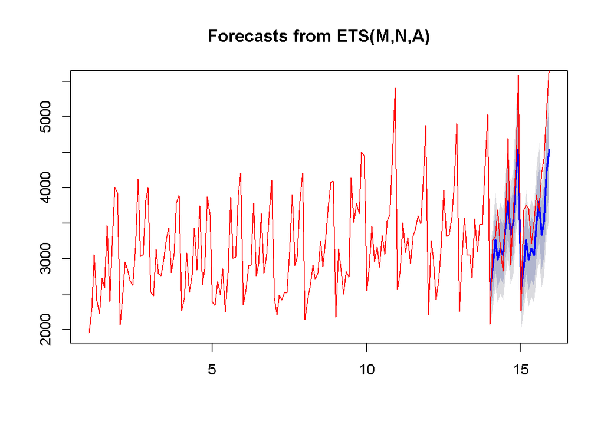

```r
fort_train.ets<-forecast::forecast(ets(fort_train))
plot(fort_train.ets)
lines(fort, col="red")
```

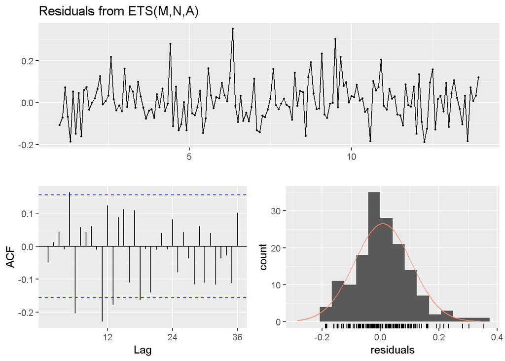

```
##
##  Ljung-Box test
##
## data:  Residuals from ETS(M,N,A)
## Q* = 48.132, df = 10, p-value = 5.871e-07
##
## Model df: 14.   Total lags used: 24
```

```r
checkresiduals(fort_train.ets)
```

Как альтернативу возьму модель MNM

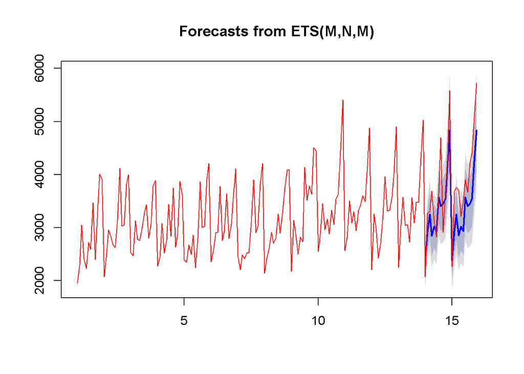

```r
fort_train.ets_MNM<-forecast::forecast(ets(fort_train,model="MNM"))
plot(fort_train.ets_MNM)
lines(fort, col="red")
```

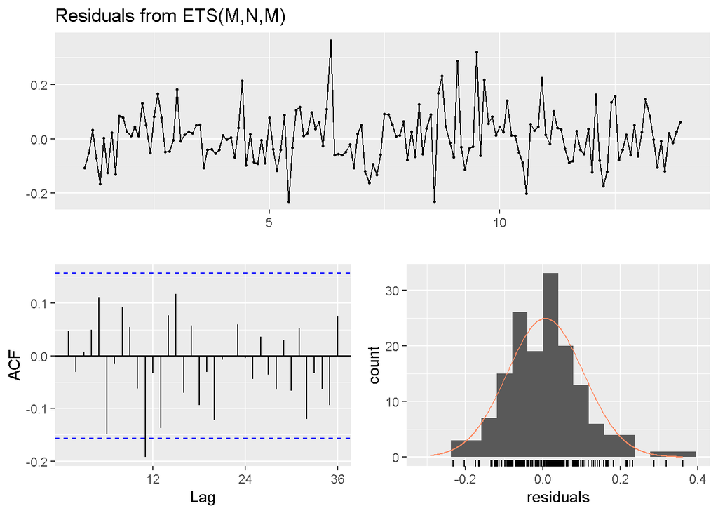

```
##
##  Ljung-Box test
##
## data:  Residuals from ETS(M,N,M)
## Q* = 29.028, df = 10, p-value = 0.001233
##
## Model df: 14.   Total lags used: 24
```

```r
checkresiduals(fort_train.ets_MNM)
```

Сравним вышеперечисленные прогнозы.

```r
ets_MNA_err<-sqrt(mean(fort_train.ets$residuals**2))
ets_MNM_err<-sqrt(mean(fort_train.ets_MNM$residuals**2))
name<-c("ets_MNA","ets_MNM")
error<-c(ets_MNA_err,ets_MNM_err)
err<-data.frame(Name=name, Error=error )
err
```

```
##      Name      Error
## 1 ets_MNA 0.09752364
## 2 ets_MNM 0.09886903
```

# 5 Прогноз

В SSA существует два типа прогноза - реккурентный и векторный.

## 5.1 Прогноз для сигнала

### 5.1.1 Vector forecast

```r
h = 24
train <- fort_train
ssa.train <- ssa(train)
```

Знаю из предыдущего отчета, какие компоненты под сигнал и тренд, но посмотрим, сколько брать компонент для тренировочной выборки.

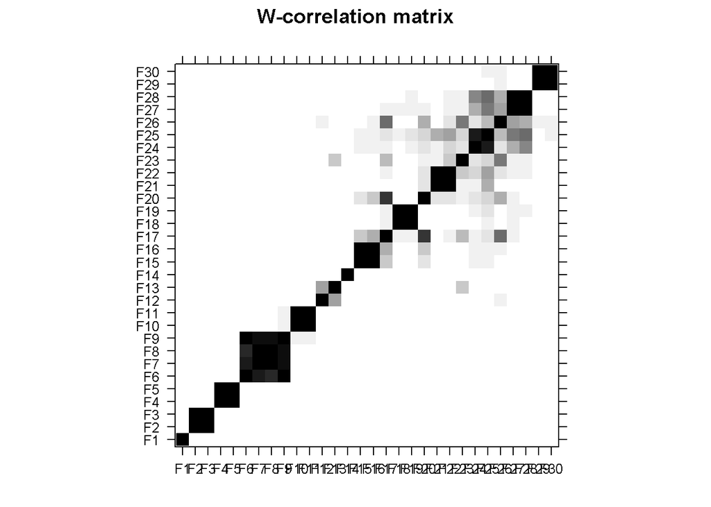

```r
plot(wcor(ssa.train, groups = 1:30))
```

Беру 14 компонент под сигнал, дальше компоненты смешиваются. Под тренд 1 и 14 компоненту.

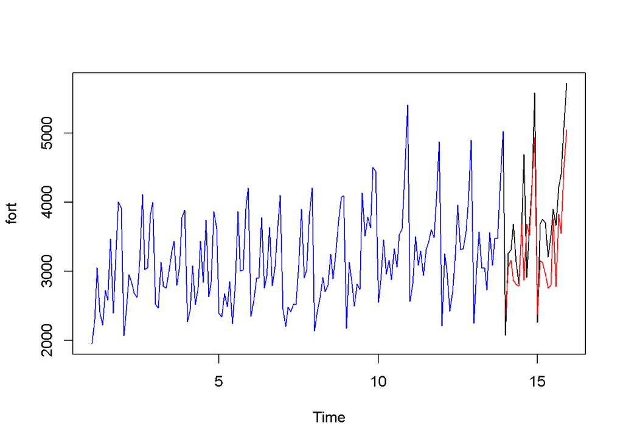

```r
#Данные компоненты взяла по предыдущему отчету
v_fort <- vforecast(ssa.train, groups = list(Trend = c(1,14), Signal = 1:14),len = 24, only.new = TRUE)
#plot(wcor(ssa.train))
plot(fort,col="black",type='l')
lines(v_fort$Signal,col="red",type="l")
lines(fort_train,col="blue")
```

Синий цвет - тренировочная выборка, красный - предсказание, черный - истина. Мне нравится как получилось.

### 5.1.2 Recurrent forecast

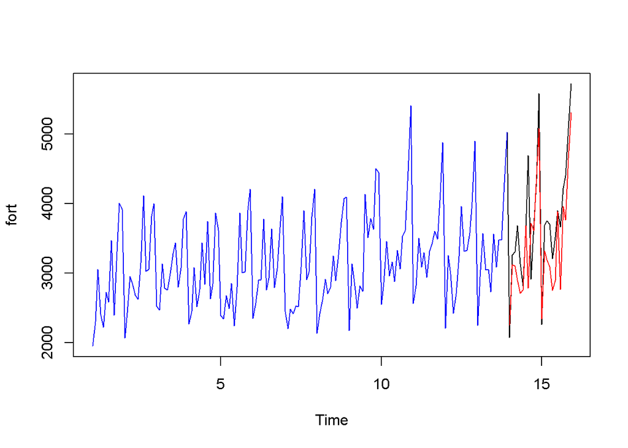

```r
r_fort <- rforecast(ssa.train, groups = list(Trend = c(1,14), Signal = 1:14),len = 24, only.new = TRUE)

plot(fort,col="black",type='l')
lines(r_fort$Signal,col="red",type="l")
lines(fort_train,col="blue")
```

```r
arima_err<-sqrt(mean(fort_train.arima$residuals**2))
v_err<-sqrt(mean((as.numeric(v_fort$Signal)-as.numeric(fort_test))**2))
r_err<-sqrt(mean((as.numeric(r_fort$Signal)-as.numeric(fort_test))**2))
name<-c("arima","Vector forecast","Recurrent forecast")
error<-c(arima_err,v_err,r_err)
err<-data.frame(Name=name, Error=error )
err
```

```
##                 Name    Error
## 1              arima 310.6486
## 2    Vector forecast 635.0244
## 3 Recurrent forecast 594.6282
```

Видим, что в данном случае arima справился лучше всех.

## 5.2 Доверительные интервалы

### 5.2.1 Vector

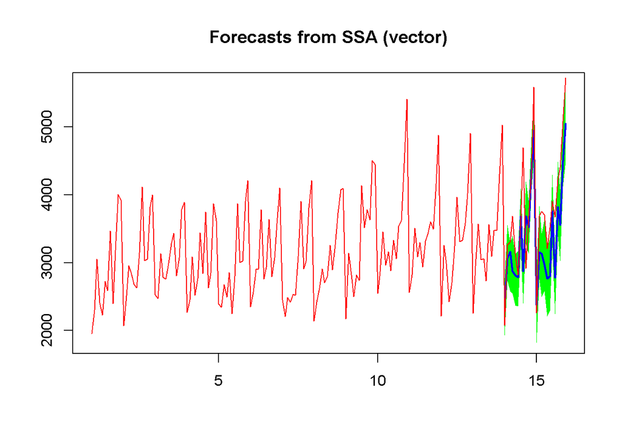

```r
library("forecast")
DI_Vec <- forecast::forecast(ssa.train, groups = list(1:14), method = "vector", interval = "confidence", bootstrap = TRUE, len = 24)
plot(DI_Vec, type = "l",  shadecols = "green")
lines(fort,col="red")
```

### 5.2.2 Recurrent

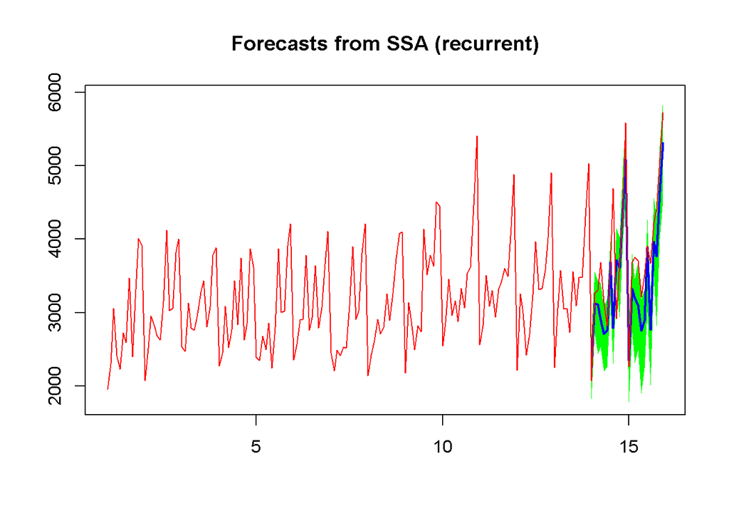

```r
DI_rec <- forecast::forecast(ssa.train, groups = list(1:14), method = "recurrent", interval = "confidence", bootstrap = TRUE, len = 24)
plot(DI_rec, type = "l",  shadecols = "green")
lines(fort,col="red")
```